# Index Numbers in R

Laspeyres, Paasche, Fisher & Törnqvist — with Pakistani CPI-style data

Data for Development (D4D) | School of Economics, QAU

## Session objectives

By the end of this session, participants will be able to:

- Explain why a single “average price” is not enough to measure inflation
- Calculate **Laspeyres**, **Paasche**, **Fisher**, and **Törnqvist** price indices by hand and in R
- Recognise the **substitution bias** built into fixed-basket indices
- Reproduce PBS-style CPI hazards: base-year switches, unstable commodity codes, unit mismatches
- Use the `IndexNumR` package for chained and multilateral indices

**Why this matters for PBS/P&D work:** every headline inflation number you report — CPI, SPI, WPI — is an index number. If you can’t defend the formula, you can’t defend the number.

## Why not just average prices?

A naive “average price change” mixes up two things that must be kept separate:

- **Price change** — did wheat get more expensive?
- **Weight** — how much wheat does a typical household actually buy?

A price index is a **weighted average of price relatives**, where the weights come from expenditure shares in a reference period.

**Note**

This is exactly what PBS does in the CPI: fix a **basket** (from HIES expenditure data), then track how much it would cost over time.

**Standard references** (cite these in any workshop or report):

- ILO, IMF, OECD, UN, World Bank (2020). *Consumer Price Index Manual: Concepts and Methods.* IMF.
- Balk, B.M. (2008). *Price and Quantity Index Numbers.* Cambridge University Press.
- Diewert, W.E. (1976). “Exact and Superlative Index Numbers.” *Journal of Econometrics*, 4(2), 115–145.

## Illustrative dataset

Structured like a PBS CPI bulletin extract: commodity groups, base-period (`p0`, `q0`) and current-period (`p1`, `q1`) prices/quantities.

**Note:** this is illustrative sample data built to mirror PBS bulletin structure for teaching — not published PBS figures. Swap in a real bulletin extract for the actual workshop run.

```r
library(tidyverse)

basket <- tibble(
  commodity_group = c("Wheat flour", "Rice", "Sugar", "Cooking oil",
                       "Pulses (masoor)", "Milk", "Electricity charges",
                       "Transport fare"),
  p0 = c(95, 145, 118, 410, 220, 130, 6.5, 40),
  q0 = c(20, 8, 6, 4, 3, 30, 250, 60),
  p1 = c(112, 162, 135, 445, 245, 142, 7.8, 46),
  q1 = c(18, 9, 6, 4, 3, 29, 240, 58)
)

basket
```

```
# A tibble: 8 x 5
  commodity_group        p0    q0    p1    q1
  <chr>               <dbl> <dbl> <dbl> <dbl>
1 Wheat flour          95      20 112      18
2 Rice                145       8 162       9
3 Sugar               118       6 135       6
4 Cooking oil         410       4 445       4
5 Pulses (masoor)     220       3 245       3
6 Milk                130      30 142      29
7 Electricity charges   6.5   250   7.8   240
8 Transport fare       40      60  46      58
```

## Audit before you calculate

Standard practice: **never** compute an index before auditing the inputs. PBS-grade habit, not optional.

```r
# Any missing prices or non-positive quantities will silently corrupt the index
basket |>
  summarise(
    n_rows = n(),
    any_na_price = anyNA(c(p0, p1)),
    any_na_qty   = anyNA(c(q0, q1)),
    any_nonpositive_price = any(c(p0, p1) <= 0),
    any_nonpositive_qty   = any(c(q0, q1) <= 0)
  )
```

```
# A tibble: 1 x 5
  n_rows any_na_price any_na_qty any_nonpositive_price any_nonpositive_qty
   <int> <lgl>        <lgl>      <lgl>                 <lgl>
1      8 FALSE        FALSE      FALSE                 FALSE
```

**PBS-specific version of this audit:** check that commodity descriptions (not numeric codes) match across periods — codes are unstable across the 2007-08 → 2015-16 base-year change.

## Laspeyres price index

Fixes the **base-period basket** (`q0`) and asks: what would it cost today?

$$L = \frac{\sum p_1 q_0}{\sum p_0 q_0} \times 100$$

```r
laspeyres <- basket |>
  summarise(L = sum(p1 * q0) / sum(p0 * q0) * 100)

laspeyres
```

```
# A tibble: 1 x 1
      L
  <dbl>
1  113.
```

- Easy to compute and update (weights fixed)
- **Overstates** inflation: assumes households keep buying the same basket even as relative prices shift
- This is the formula most national CPIs actually publish month-to-month

## Paasche price index

Fixes the **current-period basket** (`q1`) instead.

$$P = \frac{\sum p_1 q_1}{\sum p_0 q_1} \times 100$$

```r
paasche <- basket |>
  summarise(P = sum(p1 * q1) / sum(p0 * q1) * 100)

paasche
```

```
# A tibble: 1 x 1
      P
  <dbl>
1  113.
```

- **Understates** inflation: assumes households had already substituted away from goods that got relatively more expensive
- Rarely published in real time — needs current-period quantities, which usually arrive with a lag (e.g. from HIES)

## Laspeyres vs Paasche — the substitution gap

```r
bind_rows(
  tibble(index = "Laspeyres", value = laspeyres$L),
  tibble(index = "Paasche",   value = paasche$P)
)
```

```
# A tibble: 2 x 2
  index     value
  <chr>     <dbl>
1 Laspeyres  113.
2 Paasche    113.
```

**Important**

**Laspeyres ≥ Paasche** whenever quantities and prices move in opposite directions (the usual case) — this gap *is* the substitution bias, formalised by Diewert (1976).

Neither is “wrong” — they answer different questions. This is why a **superlative** index (below) is preferred when both weight sets are available.

## Fisher Ideal Index

The geometric mean of Laspeyres and Paasche — splits the difference symmetrically.

$$F = \sqrt{L \times P}$$

```r
fisher <- sqrt(laspeyres$L * paasche$P)
fisher
```

```
[1] 113.0914
```

- Satisfies more of the axiomatic “index number tests” (time reversal, factor reversal) than either component alone
- Used by the US BEA for chain-weighted GDP; recommended in the CPI Manual (2020) as a **superlative** index

## Törnqvist Index

A weighted geometric mean of price relatives, using **average expenditure shares** across the two periods.

$$\ln T = \sum_i \bar{w}_i \ln\!\left(\frac{p_{1i}}{p_{0i}}\right), \quad
\bar{w}_i = \frac{s_{0i} + s_{1i}}{2}$$

```r
tornqvist <- basket |>
  mutate(
    s0 = (p0 * q0) / sum(p0 * q0),
    s1 = (p1 * q1) / sum(p1 * q1),
    w_bar = (s0 + s1) / 2,
    log_rel = w_bar * log(p1 / p0)
  ) |>
  summarise(T = exp(sum(log_rel)) * 100)

tornqvist
```

```
# A tibble: 1 x 1
      T
  <dbl>
1  113.
```

Also **superlative** (Diewert, 1976) — very close numerically to Fisher in most real datasets.

## All four, side by side

```r
tibble(
  Index = c("Laspeyres", "Paasche", "Fisher", "Törnqvist"),
  Value = c(laspeyres$L, paasche$P, fisher, tornqvist$T)
) |>
  mutate(Value = round(Value, 2))
```

```
# A tibble: 4 x 2
  Index            Value
  <chr>            <dbl>
1 Laspeyres         113.
2 Paasche           113.
3 Fisher            113.
4 Törnqvist  113.
```

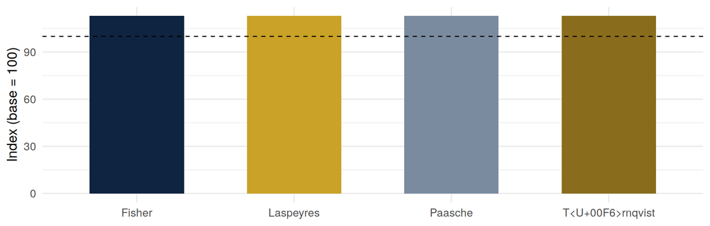

```r
tibble(
  Index = c("Laspeyres", "Paasche", "Fisher", "Törnqvist"),
  Value = c(laspeyres$L, paasche$P, fisher, tornqvist$T)
) |>
  ggplot(aes(x = Index, y = Value, fill = Index)) +
  geom_col(width = 0.6) +
  geom_hline(yintercept = 100, linetype = "dashed") +
  scale_fill_manual(values = c("#0f2440", "#c9a227", "#7a8ba0", "#8a6d1c")) +
  labs(y = "Index (base = 100)", x = NULL) +
  theme_minimal(base_size = 14) +
  theme(legend.position = "none")
```

## Pakistan-specific hazards

**Commodity codes are unstable.** PBS revised the CPI basket and codes at the 2007-08 → 2015-16 base-year change. Always join across periods on **description text**, not numeric codes — then audit with `anti_join()` to catch anything that fails to match.

**Units differ across sources.** WFP price bulletins mix KG, 20KG, 500G and Litre units for the same commodity. Reconcile to a common unit **before** any price averaging, or the index is meaningless.

**Provincial coverage gaps.** Islamabad sometimes appears unlabeled (e.g. as a bare code) in provincial breakdowns — check factor levels with `as_factor()` before aggregating by province.

```r
# The pattern to teach every time, before any join:
intersect(names(pbs_period_a), names(pbs_period_b))
anti_join(pbs_period_a, pbs_period_b, by = "commodity_description")
```

## Chained indices

Fixed-base indices drift as the basket ages. **Chaining** links period-to-period movements instead of comparing everything back to one distant base.

$$\text{Chained}_t = \text{Chained}_{t-1} \times \frac{I_{t-1,t}}{100}$$

```r
# Three periods of Laspeyres link relatives (illustrative)
link_relatives <- tibble(period = 2:4, link_index = c(103.2, 101.8, 104.5))

link_relatives |>
  mutate(chained_index = 100 * cumprod(link_index / 100))
```

```
# A tibble: 3 x 3
  period link_index chained_index
   <int>      <dbl>         <dbl>
1      2       103.          103.
2      3       102.          105.
3      4       104.          110.
```

Trade-off: chaining tracks current consumption patterns more closely, but **chain drift** can appear if prices oscillate (e.g. seasonal food items) rather than trend.

## Using `IndexNumR`

For real multi-period, multi-product panels, don’t hand-roll the loops — `IndexNumR` (White) implements Laspeyres, Paasche, Fisher, Törnqvist, and **GEKS** multilateral indices.

```r
install.packages("IndexNumR")
library(IndexNumR)
```

```r
# IndexNumR expects long format: period, product ID, price, quantity
panel <- basket |>
  mutate(product_id = row_number()) |>
  pivot_longer(cols = c(p0, p1, q0, q1),
               names_to = c(".value", "period"),
               names_pattern = "([a-z]+)(\\d)") |>
  mutate(period = as.integer(period) + 1L)

price_index(panel, pvar = "p", qvar = "q",
            pervar = "period", prodID = "product_id",
            indexMethod = "fisher")
```

**Reference:** White, G. *IndexNumR: An R Package for Index Number Calculation.* CRAN.

## Hands-on exercise

Using `basket` (or a real PBS/WFP extract you bring):

1. Recompute Laspeyres and Paasche **swapping** which period supplies the weights — confirm the substitution-bias inequality holds
2. Add a fifth commodity where price **falls** between periods — does Laspeyres still exceed Paasche?
3. Reshape `basket` into long format and reproduce the Fisher index using `IndexNumR::price_index()`
4. **Stretch:** chain three periods of your own link relatives and plot the chained series with `ggplot2`

**Note**

Print every audit step. If a number looks wrong, the fix is almost always in the join or the unit conversion — not the formula.

## References

- International Labour Organization, IMF, OECD, UN, World Bank (2020). *Consumer Price Index Manual: Concepts and Methods.* International Monetary Fund.
- Balk, B.M. (2008). *Price and Quantity Index Numbers: Models for Measuring Aggregate Change and Difference.* Cambridge University Press.
- Diewert, W.E. (1976). “Exact and Superlative Index Numbers.” *Journal of Econometrics*, 4(2), 115–145.
- White, G. *IndexNumR: An R Package for Index Number Calculation.* CRAN: `https://cran.r-project.org/package=IndexNumR`
- Pakistan Bureau of Statistics. *Consumer Price Index* methodology notes and bulletins. `https://www.pbs.gov.pk`

## Wrap-up

- An index number is a **weighted average of price relatives** — the weights are the whole story
- **Laspeyres** (fixed base basket) is what gets published monthly; **Paasche** needs current weights and lags
- **Fisher** and **Törnqvist** are *superlative* — the workshop standard when both weight sets exist
- For Pakistani data specifically: **audit joins on description text**, **reconcile units first**, **never trust a numeric commodity code across base-year changes**

**Next session:** applying this pipeline to a real PBS CPI bulletin extract, end to end.

D4D Workshop | Index Numbers in R